```
DB_PATH resolved to: C:\Users\scgee\OneDrive\Documents\Projects\PatientPunk-pr37\docs\RCT_historical_validation\data\historical_validation_2020-07_to_2022-12.db
```

# RCT Historical Validation — Reproducibility Figures

This notebook reproduces **Figure 1**, **Figure 2**, **Table 2**, and **Table 3** from the paper.

- **Figure 1**: Per-drug full sentiment breakdown (positive / mixed / neutral / negative, stacked bar)
- **Figure 2**: Pre-publication community sentiment — responders vs non-responders for 6 drugs (forest plot)
- **Table 2**: Data sources by drug (databases, window, post/user/report counts)
- **Table 3**: Per-drug response composition with Wilson 95% CIs and binomial test p-values

**Method.** For each drug, we extract all treatment-sentiment reports from r/covidlonghaulers posts whose `post_date` is strictly before the comparator paper's first public release (medRxiv preprint or journal online-first, whichever came first). The SQL predicate is literally `p.post_date < pub_date_in_unix_seconds`, where `pub_date` is the midnight-UTC timestamp of the publication date — so any post on or after the publication date is excluded by construction. The analysis is additionally capped at end of 2022 (i.e., posts on or after 2023-01-01 are excluded) for paxlovid and colchicine. All classified reports come from a single self-sufficient SQLite database (`historical_validation_2020-07_to_2022-12.db`). Posts where the Reddit author field was `[deleted]` or `[removed]` (mapped to the placeholder user_id `"deleted"`) are excluded from per-user analysis: those posts come from many distinct real users whose accounts no longer exist, and collapsing them under one pseudo-user would give that whole population one vote per drug. Each remaining user contributes exactly one data point per drug after deduplication: the **most recent report** wins (by full UTC timestamp), with **signal_strength** as the tiebreaker on exact timestamp ties (strong > moderate > weak > n/a). Exact-timestamp ties are rare, so the tiebreaker fires only occasionally — the rule reduces in practice to "most recent post wins." We then test whether the proportion of responders (positive sentiment) differs from a 50% null using a two-sided binomial test.

```
DB integrity check: 0 mismatched user_ids (must be 0). PASS.
```

## Expected-output assertion

The cell below compares the freshly-computed `resp_df` against a frozen expected-output table (defined as `EXPECTED_OUTPUTS` in the setup cell). Build fails on any drift outside rounding tolerance — so a future analytical change that silently shifts a number can't slip through.

The check is intentionally strict on integer counts (`n`, `pos`) and loose on rounding (`pos_pct` to 0.05pp, `p` relative tolerance 1e-3 for non-tiny p-values; for p < 1e-4 we just check the order of magnitude matches). Update `EXPECTED_OUTPUTS` *and* the README's "Expected Output" table together if the analytical pipeline legitimately changes.

```
V10 expected-output assertion: all 6 drugs match the frozen table. PASS.
```

## Figure 1 — Full sentiment breakdown per drug

Figure 2 collapses the four sentiment classes into a binary responder vs. non-responder split. Figure 1 retains the full four-way breakdown (positive / mixed / neutral / negative) so the shape of the non-responder bucket is visible. Per-segment labels show both the percentage and the raw user count contributing to that segment.

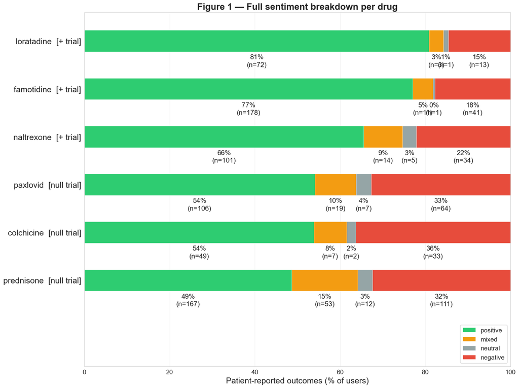

## Figure 2 — Forest plot: responders and non-responders by drug

Figure 2 collapses the four-way sentiment breakdown into a binary split: responders (positive sentiment) vs. non-responders (negative + neutral + mixed). Each drug contributes two points to the forest plot — a green circle for the **responder** rate and a red square for the **non-responder** rate — both with their 95% Wilson confidence intervals. The row label gives the drug, the comparator trial outcome (`[+ trial]` vs `[null trial]`), the paper citation, and the sample size.

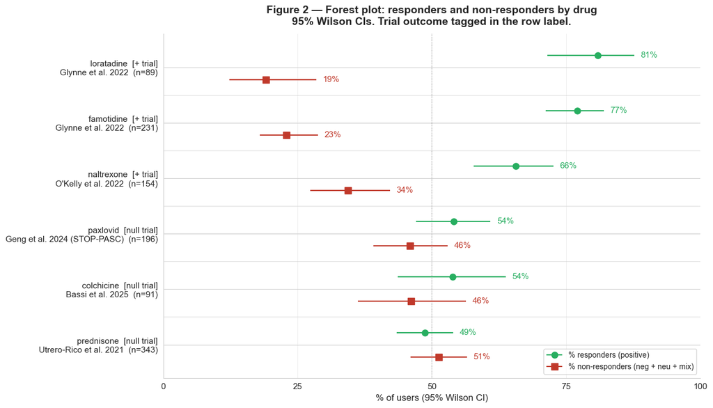

## Data sources and methodology

**Definitions:**

- **Responder**: user's selected report has `positive` sentiment.
- **Non-responder**: user's selected report has any other sentiment (negative, neutral, or mixed).

**Per-(user, drug) deduplication rule:**

- Most recent post wins (full UTC timestamp, descending).
- On exact-timestamp ties, the report with stronger `signal_strength` wins (strong > moderate > weak > n/a). Such ties are rare, so this step is a near-vestigial tiebreaker — the rule reduces in practice to "most recent post wins."

Table 2 — Data sources by drug

| Drug | Window | Total posts | Unique users | Treatment reports | Comparator paper |
| --- | --- | --- | --- | --- | --- |
| famotidine | 2020-07-24 → 2021-06-05 | 138,615 | 231 | 692 | Glynne et al. 2022 (medRxiv 2021-06-06) |
| loratadine | 2020-07-24 → 2021-06-05 | 138,615 | 89 | 188 | Glynne et al. 2022 (medRxiv 2021-06-06) |
| prednisone | 2020-07-24 → 2021-10-25 | 218,822 | 343 | 790 | Utrero-Rico et al. 2021 (Biomedicines 2021-10-26) |
| naltrexone | 2020-07-24 → 2022-07-02 | 448,114 | 154 | 583 | O'Kelly et al. 2022 (BBI Health 2022-07-03) |
| paxlovid | 2020-07-24 → 2022-12-31 | 678,923 | 196 | 488 | Geng et al. 2024 (STOP-PASC) (JAMA Intern Med 2024-06-07) |
| colchicine | 2020-07-24 → 2022-12-31 | 678,923 | 91 | 211 | Bassi et al. 2025 (JAMA Intern Med 2025-10-20) |

All counts are drawn from a single SQLite database (`historical_validation_2020-07_to_2022-12.db`) constructed for this paper. **Total posts:** all r/covidlonghaulers posts in the drug's window with non-NULL `post_date` and non-deleted `user_id` — the denominator the substring + LLM extraction ran against. **Unique users:** distinct users with at least one classified report for the drug (after deleted-user exclusion). **Treatment reports:** total post-level classified reports before per-user dedup. Window cap at end of 2022 applies to paxlovid and colchicine; for the other four drugs the comparator publication date is the binding cutoff.

Table 3 — Per-drug response composition (pre-publication data only)

Each row: one (user, drug) per cell after the *most recent + signal-strength tiebreaker* dedup rule. Responders = positive sentiment; non-responders = negative + neutral + mixed. *p* values from a two-sided binomial test against the 50% null (H₀: P(responder) = 0.5). The 'Source / first public date' column gives the earliest publicly available release of the comparator paper (medRxiv preprint where available, otherwise journal online-first).

| drug | Comparator paper | Source / first public date | n | % responders | responders 95% CI | -/0/~ | % non-resp | non-resp 95% CI | p (vs 50%) |
| --- | --- | --- | --- | --- | --- | --- | --- | --- | --- |
| loratadine | Glynne et al. 2022 | medRxiv 2021-06-06 | 89 | 80.9% | [71.5%, 87.7%] | 17 | 19.1% | [12.3%, 28.5%] | 3.17e-9 |
| famotidine | Glynne et al. 2022 | medRxiv 2021-06-06 | 231 | 77.1% | [71.2%, 82.0%] | 53 | 22.9% | [18.0%, 28.8%] | 5.51e-17 |
| naltrexone | O'Kelly et al. 2022 | BBI Health 2022-07-03 | 154 | 65.6% | [57.8%, 72.6%] | 53 | 34.4% | [27.4%, 42.2%] | 1.36e-4 |
| paxlovid | Geng et al. 2024 (STOP-PASC) | JAMA Intern Med 2024-06-07 | 196 | 54.1% | [47.1%, 60.9%] | 90 | 45.9% | [39.1%, 52.9%] | 0.284 |
| colchicine | Bassi et al. 2025 | JAMA Intern Med 2025-10-20 | 91 | 53.8% | [43.7%, 63.7%] | 42 | 46.2% | [36.3%, 56.3%] | 0.530 |
| prednisone | Utrero-Rico et al. 2021 | Biomedicines 2021-10-26 | 343 | 48.7% | [43.4%, 54.0%] | 176 | 51.3% | [46.0%, 56.6%] | 0.666 |

## Dedup audit

For each drug we report:

- **Raw reports**: total `treatment_reports` rows in-window (pre-dedup).
- **Unique users**: `COUNT(DISTINCT user_id)` over the same set — this is the `n` that appears in Figure 2 / Table 3 after dedup.
- **Multi-report users**: users with ≥2 in-window reports for this drug. Dedup only matters for these.
- **Mixed-signal users**: multi-report users whose reports contain *both* positive and non-positive labels — the population where the dedup rule choice actually changes the class assignment.
- **Flipped under alternative rules**: how many users would land in a different responder/non-responder bucket if we used "majority sentiment" or "any-positive ⇒ positive" instead of our "most-recent + signal-strength tiebreaker" rule. This is the dedup-rule sensitivity check.

A small flip count (relative to total users) means the headline numbers are robust to the choice of dedup rule. A large flip count would mean the analysis is sensitive to dedup methodology and we should be more careful about justifying the rule.

Dedup audit — raw vs unique counts + rule sensitivity

| drug | raw reports | unique users | multi-report users | mixed-signal users | final n (pos) | flips: majority rule | flips: any-positive rule |
| --- | --- | --- | --- | --- | --- | --- | --- |
| famotidine | 692 | 231 | 113 | 32 | 178 | 11 (4.8%) | 14 (6.1%) |
| loratadine | 188 | 89 | 39 | 9 | 72 | 3 (3.4%) | 5 (5.6%) |
| prednisone | 790 | 343 | 131 | 67 | 167 | 26 (7.6%) | 36 (10.5%) |
| naltrexone | 583 | 154 | 72 | 36 | 101 | 11 (7.1%) | 14 (9.1%) |
| paxlovid | 488 | 196 | 84 | 36 | 106 | 13 (6.6%) | 13 (6.6%) |
| colchicine | 211 | 91 | 38 | 21 | 49 | 8 (8.8%) | 9 (9.9%) |

*flips: majority rule* = users who would have landed in a different responder bucket under the rule "majority of reports" instead of "most recent + signal-strength tiebreaker." *flips: any-positive rule* = same but under the rule "any positive report → responder." Smaller is more robust.

```
Dedup audit: 6 drugs audited.
  famotidine   raw= 692 users= 231 multi=113 mixed= 32 flip(maj)= 11 flip(any+)= 14
  loratadine   raw= 188 users=  89 multi= 39 mixed=  9 flip(maj)=  3 flip(any+)=  5
  prednisone   raw= 790 users= 343 multi=131 mixed= 67 flip(maj)= 26 flip(any+)= 36
  naltrexone   raw= 583 users= 154 multi= 72 mixed= 36 flip(maj)= 11 flip(any+)= 14
  paxlovid     raw= 488 users= 196 multi= 84 mixed= 36 flip(maj)= 13 flip(any+)= 13
  colchicine   raw= 211 users=  91 multi= 38 mixed= 21 flip(maj)=  8 flip(any+)=  9
```

## Window verification

For each drug we report the actual `MIN(p.post_date)` and `MAX(p.post_date)` of the classified reports the analysis includes. The `MAX` must be strictly before `window_end_exclusive` (the publication-date midnight, or 2023-01-01 for the end-of-2022 cap); the cell below asserts this and fails the build if any drug includes an out-of-window report. We also confirm zero `post_date IS NULL` rows enter the per-drug analysis.

This complements the SQL predicate `p.post_date < window_end_exclusive_ts` in `fetch_drug_reports()` — that predicate *prevents* leakage; this audit *proves* it didn't leak.

| drug | pub_date | win_end_excl | actual min | actual max | n (pre-dedup) | nulls | in window? |
| --- | --- | --- | --- | --- | --- | --- | --- |
| famotidine | 2021-06-06 | 2021-06-06 | 2020-08-05 03:42 UTC | 2021-06-05 20:40 UTC | 692 | 0 | ✓ |
| loratadine | 2021-06-06 | 2021-06-06 | 2020-08-18 16:26 UTC | 2021-06-05 22:42 UTC | 188 | 0 | ✓ |
| prednisone | 2021-10-26 | 2021-10-26 | 2020-07-28 22:42 UTC | 2021-10-23 19:06 UTC | 790 | 0 | ✓ |
| naltrexone | 2022-07-03 | 2022-07-03 | 2020-10-12 04:41 UTC | 2022-07-02 20:02 UTC | 583 | 0 | ✓ |
| paxlovid | 2024-06-07 | 2023-01-01 | 2022-01-18 05:13 UTC | 2022-12-31 18:35 UTC | 488 | 0 | ✓ |
| colchicine | 2025-10-20 | 2023-01-01 | 2020-08-29 10:55 UTC | 2022-12-29 12:45 UTC | 211 | 0 | ✓ |

```
Window verification: all 6 drugs in-window, 0 NULL post_dates. PASS.
```

## Pipeline provenance — `extraction_runs`

This table is the build-DB's record of *which pipeline run produced every classified report it contains*. Each row links a `run_id` to the git commit that ran it, the run timestamp, and the run config (models used, target drug, etc.). The same `run_id` is foreign-keyed onto every `treatment_reports` row, so any number in Figure 2 / Table 3 can be traced back to the exact pipeline invocation that produced it.

A machine-readable copy of this table — together with the build-time git commit, DB SHA-256, and model env — is also written to `output/provenance.json` at the end of the build.

extraction_runs — pipeline provenance for this DB

| run_id | run_at | commit | type | drug | fast model | strong model |
| --- | --- | --- | --- | --- | --- | --- |
| 1 | 2026-05-02 22:08 UTC | 16c2569b02 | treatment_sentiment | famotidine | anthropic/claude-haiku-4.5 | anthropic/claude-sonnet-4.6 |
| 2 | 2026-05-02 22:22 UTC | 16c2569b02 | treatment_sentiment | loratadine | anthropic/claude-haiku-4.5 | anthropic/claude-sonnet-4.6 |
| 3 | 2026-05-02 22:29 UTC | 16c2569b02 | treatment_sentiment | prednisone | anthropic/claude-haiku-4.5 | anthropic/claude-sonnet-4.6 |
| 4 | 2026-05-02 22:39 UTC | 16c2569b02 | treatment_sentiment | naltrexone | anthropic/claude-haiku-4.5 | anthropic/claude-sonnet-4.6 |
| 5 | 2026-05-02 22:46 UTC | 16c2569b02 | treatment_sentiment | paxlovid | anthropic/claude-haiku-4.5 | anthropic/claude-sonnet-4.6 |
| 6 | 2026-05-02 22:51 UTC | 16c2569b02 | treatment_sentiment | colchicine | anthropic/claude-haiku-4.5 | anthropic/claude-sonnet-4.6 |

6 pipeline run(s) in this DB. Every classified `treatment_report` row is foreign-keyed to one of these `run_id`s.